# Three Gemma 4 Deployments on One T4G for Under $3: What the Runtime Changes, and What It Doesn't

This article provides a step by step comparison of three Gemma 4 deployments on a single AWS hosted GPU enabled system. A suite of Python MCP tools is built to simplify management of each deployment, and one benchmark harness is shared across all three so that the runtime is the only variable.

https://github.com/xbill9/gemma4-dev

The whole exercise cost under three dollars, and that is the part worth keeping. Nineteen instances and about four and a half instance-hours bought three serving sweeps, nine timed boots and a handful of A/B restarts. It also bought five wrong claims, each caught by measuring instead of reasoning. On hardware where a run is expensive, the cheapest of those five would have shipped with a caveat attached.

#### What is this project trying to Do?

Three rigs in this monorepo serve `google/gemma-4-E2B-it` on an AWS G5g instance. One runs vLLM, one runs a pure JAX port, one runs PyTorch with transformers. The hardware is identical and only the runtime slot moves, so this should be the cleanest A/B available.

For months it was not, because each rig measured itself with its own harness and quoted its own number. Three harnesses computing three statistics is not a comparison.

#### Prerequisites

- An AWS account with G-family quota in `us-east-1`. Each `g5g.2xlarge` is 8 vCPU, so 16 vCPU of spot quota runs two at once.
- A subnet, a security group opening TCP 8000, and an instance profile carrying `AmazonSSMManagedInstanceCore` plus read on the Hugging Face token secret.
- A Hugging Face token in Secrets Manager. It is fetched at boot into a root-only `EnvironmentFile` and never appears in user data.
- `boto3` and the standard credential chain. No AWS CLI shell-outs, no inbound SSH rule, and no private key anywhere in the flow.

#### AWS EC2 G5g

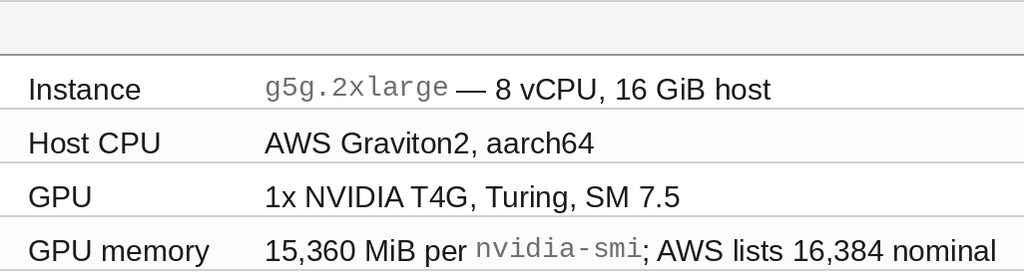

G5g is the only family AWS ships that puts an NVIDIA GPU behind a Graviton host, which makes it the only place to get aarch64 and compute capability 7.5 together.

#### Gemma 4 E2B

`google/gemma-4-E2B-it` is the reference instruction-tuned release. It is 2B effective from about 5B total, and the split matters here: most of what is resident is a per-layer-embedding table that decode reads as a gather and never streams through a matmul.

The dense checkpoint fits. 9.5 GiB of float16 weights go into 15,360 MiB of device memory with room for the KV cache, which at roughly 18 KiB per token is tens of megabytes at this context and never the binding constraint.

#### The Three Runtimes

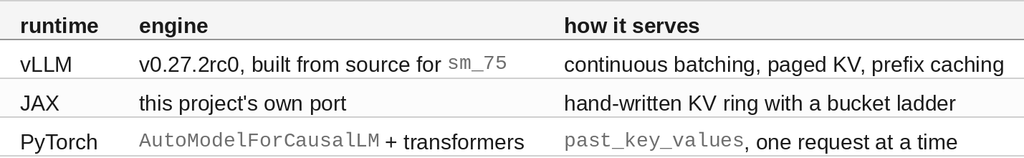

Turing has no bfloat16 datapath, so all three run float16. It has no fp8 either, which rules out the KV-cache tricks that work on newer parts.

#### Check the Quotas

```
check_g5g_quotas
```

```
| Quota | vCPUs |
| Running On-Demand G and VT instances (vCPU) | 16 |
| All G and VT Spot Instance Requests (vCPU) | 16 |

`g5g.2xlarge` needs 8 vCPUs.
```

That is the constraint behind every launch below: two rigs in parallel, and no more.

#### The Sweep Could Not See vLLM

The sweep script read its throughput figure straight out of the response body:

```python
"decode_tps": usage.get("decode_tokens_per_second", 0.0),
```

`usage.decode_tokens_per_second` is a field our own servers invent. vLLM does not emit it, and neither does anything else, so the harness could not be pointed at the vLLM rig at all. The three-way comparison had never actually been run.

Re-running a rig does not fix that. Only a common statistic does.

#### One Statistic, Three Servers

Every OpenAI-compatible server streams, so the portable measurement is the gap between tokens on the wire.

```bash
python3 sweep.py --help | grep -A2 decode-source
```

```
  --decode-source {auto,usage,stream,both}
                        where the decode figure comes from; see the module
                        docstring
```

The `stream` path uses `vllm bench serve`'s exact TPOT definition, `(latency - ttft) / (output_len - 1)`, so a number from this harness is directly comparable to that tool's published figures. `auto` probes the endpoint once and picks `both` where the server emits its own gauge, `stream` where it does not.

#### Is the Calibration Transferable?

No, and that is worth a measurement rather than an assumption. Running `both` measures each rig's offset between the two statistics.

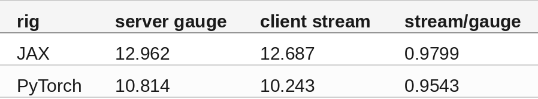

Two percent against 4.6 percent, on the same day and the same instance shape. Borrowing one rig's ratio to convert the other's number would inject a 2.6 percent error into a comparison whose smallest interesting gap is 24 percent. The cross-rig table below is therefore built from `stream` throughout.

#### A Gauge Rounded to One Decimal

The JAX server emitted its decode gauge with one decimal place:

```python
f'tpu_jax_decode_tokens_per_second{{model="{MODEL_ID}"}} {METRICS["last_tokens_per_second"]:.1f}',
```

At about 13 tok/s, one decimal is 0.78 percent resolution. Every sweep that rig had produced showed all three repeats of a cell as byte-identical: 12.8, 12.8, 12.8. That is not reproducibility, it is the measurement floor. The rig had been used to argue about two percent effects it could not resolve.

Two characters fixed it. The first run afterwards reads 12.962, where before it would have said 13.0.

#### Launch the Instance

Capacity for the whole G5g family was exhausted across all four availability zones several times, so the launcher cycles them with a sixty second backoff.

```
[12:51:45] round 5 us-east-1c: ❌ AWS InsufficientInstanceCapacity
[12:52:47] us-east-1a: ✅ Launching `i-02e79988a6cbeecbf` (g5g.2xlarge, spot, 1x T4G) in `us-east-1`.
```

The walkthrough from here follows the PyTorch rig on `i-02e79988a6cbeecbf`; the other two run the same steps against their own instances. All three landed in `us-east-1a` within hours of each other. Note that AWS names the other zones as available in every one of those errors — that text describes on-demand capacity and says nothing about spot.

#### Watch the Install

Cloud-init installs the runtime and then backgrounds itself, so the progress tool reports cloud-init's own state as well as the install log. A dead bootstrap and a slow one must not render identically.

```
get_install_progress i-02e79988a6cbeecbf
```

```
INSTALL COMPLETE
--- cloud-init ---
status: done
errors: []
```

#### Verify the GPU

A config flag being accepted proves nothing, so the probe runs a real matmul on the device.

```
verify_gpu_arch i-02e79988a6cbeecbf
```

```
NVIDIA T4G, 7.5, 15360 MiB
torch: 2.12.0+cu132
arch_list: ['sm_75', 'sm_80', 'sm_90', 'sm_100', 'sm_110', 'sm_120']
capability: (7, 5)
compute_dtype: float16
fp16 matmul ok: True

✅ torch reached the GPU and a real fp16 matmul executed.
```

The DLAMI's torch carries `sm_75`. Upstream PyPI aarch64 wheels do not, so a `pip install torch` on this box would serve on CPU without saying so.

#### Deploy the Server

The payload is the rig's own source, shipped over SSM as a gzipped tarball because user data caps at 16 KiB.

```
deploy_torch_server i-02e79988a6cbeecbf
```

```
✅ Deployed 3 files (16 KiB base64) to `i-02e79988a6cbeecbf`.

Payload root: `/home/xbill/gemma4-dev/gpu-pytorch-g5g-2b`
Build id: `060a572aeb55` — verify_model_health checks the running server reports this.
```

#### Verify the Installation

A non-empty reply is not evidence of health. One sibling was once measured answering `': ok: ok: ok…'`, so the check reads the server's own degenerate-response counter either side of its probe, and compares the served build id against the local payload.

```
verify_model_health i-02e79988a6cbeecbf
```

```
✅ health=200 tokens=5 reply='ok'

- Degenerate (server's own verdict on the full text): **no**
- Build id served: `060a572aeb55`
- Build id matches the local payload (`060a572aeb55`).
```

#### Run the Sweep

The same command runs against all three rigs. Only the endpoint changes.

```bash
python3 sweep.py --base http://<ip>:8000/v1 --out benchmarks/runs/<run> \
  --contexts 64,512,1024,2048,3072,3800 --outputs 32,128 --repeats 3 \
  --decode-source both
```

```
decode-source: both -> both
ctx~512 out=32: in=633 out=32 decode=10.96 tok/s  e2e=9.83 tok/s (warmup 11.08)  stream/usage=0.9616
ctx~2048 out=128: in=2501 out=89 decode=10.66 tok/s  e2e=9.16 tok/s (warmup 10.61)  stream/usage=0.9540
ctx~3800 out=32: FAILED HTTP Error 400 {"detail":"prompt is 4630 tokens and the context
  bound is 4096, leaving no room to decode. Start the server with a larger --seq."}
```

Cells that cannot exist on the hardware are recorded as `infeasible` rather than dropped. An absent cell is indistinguishable from an untried one, which is how a sweep overstates its own coverage.

#### Decode at Concurrency One

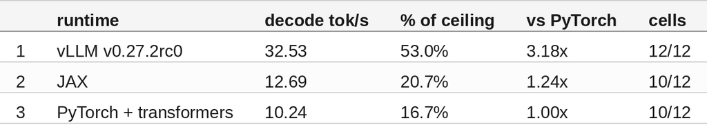

#### How Close Is That to the Hardware?

The ceiling is arithmetic, not a measurement. E2B streams 4.514 GB of weights per decode step against a measured 277 GB/s, giving 16.30 ms per step and **61.4 tok/s**.

The PLE table is excluded from that figure because it is a gather and never a matmul. Quantising it from 9.257 GB to 5.752 GB moved decode by 0.00 tok/s across three cells, which is what confirms it never streams.

All three runtimes sit far below the ceiling, so **none of them is bandwidth-bound at batch one**. The PyTorch profile shows why: about 5,650 kernel launches per step at one to three microseconds each, on a chip whose launch overhead is five to ten.

#### The Number I Did Not Expect

Time to first token was the result of the run, right up until it was checked.

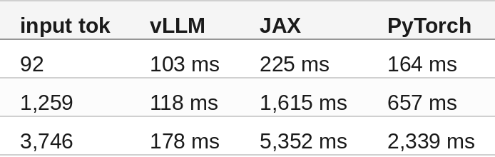

A 30x advantage, far larger than the 3.2x on decode. It is also impossible. Prefill at 3,746 tokens is roughly 14 TFLOP against a T4G's realistic 20 to 30 TFLOP/s, which is 460 ms at best. vLLM's row says 178 ms.

It did not. vLLM ships `enable_prefix_caching=True`, and its own metrics say so:

```bash
grep -E "^vllm:prefix_cache_(queries|hits)_total" metrics.prom
```

```
vllm:prefix_cache_queries_total{engine="0"} 102898.0
vllm:prefix_cache_hits_total{engine="0"}     97440.0
```

**A 94.7 percent hit rate.** vLLM genuinely prefilled 5.3 percent of the tokens it was sent, because the harness reused one prompt for a cell's warm-up and all three repeats. Neither sibling has a prefix cache, so both paid full prefill every time.

The fix places a nonce first in the prompt, since a shared prefix is exactly what the cache keys on and a trailing nonce would not have defeated it. That property is now a unit test.

#### What the Prefill Data Does Support

Strip the contaminated column and a real result remains. Neither of the other two runtimes caches prefixes, and both saw identical prompts.

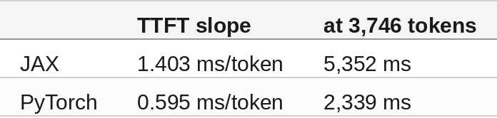

**JAX prefills 2.4x slower than PyTorch**, consistently across all five shared context lengths. On an interactive workload with real context that dominates user-visible latency, and it runs in the opposite direction to the 1.24x decode advantage the same rig enjoys.

#### Boot Time Reverses the Ranking

Nine cold boots, three per runtime, plus nine warm reloads. The start line is the moment `run_instances` returns an id, because capacity wait measures AWS rather than the rig.

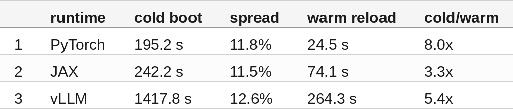

**vLLM takes 23m 38s to serve, from a prebuilt AMI that downloads nothing.** PyTorch installs its runtime from wheels and pulls the 9.54 GiB checkpoint over the network, and is still 7.3x faster.

Boot variance is 11.5, 11.8 and 12.6 percent — too consistent across three different runtimes to be a property of any of them. This family's decode noise floor is 1.7 percent, measured by running an identical build on two hosts, so boot is about seven times noisier and a single boot measurement is close to worthless.

#### Is Health 200 the Same as Ready?

Not on every runtime, which is why the harness records two stop lines.

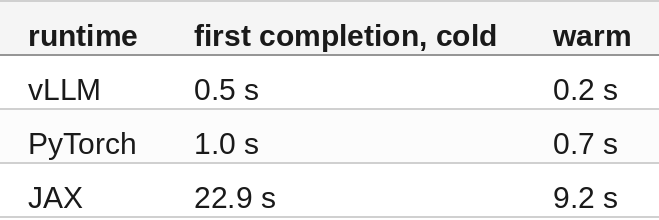

JAX returns health 200 and then compiles XLA per shape bucket on the first real request. Quoting health alone understates its time to serving by 22 seconds, and the cost does not vanish when warm. vLLM is the mirror image: slowest to boot, fastest first token, because graph capture is paid before the port binds.

#### What Does a Code Change Cost?

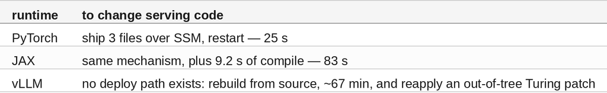

#### Five Theories About 546 Seconds

vLLM's cold boot is dominated by weight loading: 468 to 561 seconds across four measurements. Explaining it took five attempts, four of which were wrong.

1. *`g5g.2xlarge` needs no swapfile and buys that time back.* The rig's own documentation. Falsified by the three-boot campaign at 23m 38s.
2. *A bigger host will not fix it.* Retracted the same day — no large host had been measured.
3. *A larger host would very plausibly fix it.* Falsified by one `g5g.4xlarge` boot: available RAM 11.19 to 26.49 GiB, weight loading 546 to 468 s, and total boot 4.7 percent lower, inside the noise band.
4. *It is the loader; vLLM's log says auto-prefetch is disabled on EXT4.* Falsified by a within-box A/B — 76.13 s as shipped against 75.12 s with `--safetensors-load-strategy=prefetch`, which is 1.3 percent and therefore nothing.

What that last run did find is the useful part.

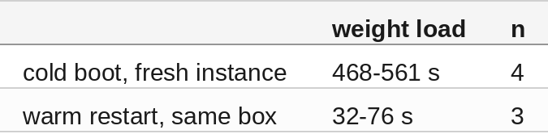

Same volume, same filesystem, same engine, differing only in whether the blocks had been read once. 9.54 GiB in 468 s is about 21 MiB/s, which is absurd for gp3 steady state and ordinary for first-touch reads against a snapshot-backed volume.

Theory five is EBS lazily hydrating the volume from the AMI snapshot, and it is written down as untested. Given the strike rate it does not get promoted by reasoning.

#### Why the First Campaign Was Thrown Away

The data was not wrong; the campaign log shows 215 s and 216 s of wall clock. It was unusably coarse. Health polling went to half a second, and the next pair of boots came in at 216.90 s and 193.86 s — an 11.9 percent spread the old harness could not see.

#### And Price/Performance?

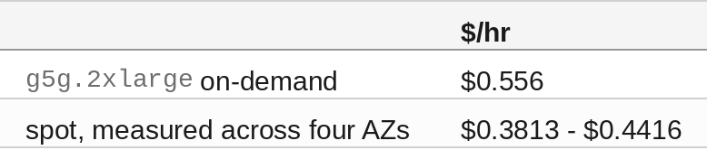

The whole exercise — 19 instances, 4.06 hours of `g5g.2xlarge` plus 0.38 of `g5g.4xlarge`, a serving sweep, three cross-rig runs, nine boots and three A/B restarts — came to under $3. That is arithmetic rather than a bill: AWS drops terminated instances after an hour, so the derivation in `cost_derivation.md` bounds it at $1.84 all-spot and $2.68 all-on-demand.

That 26 to 46 percent premium is the entire spot versus on-demand decision on this hardware, which is to say there is not one. Try spot, fall back, keep working; the automatic fallback cost about $0.24 across a nine-boot campaign.

**Cheap hardware is what made the method possible, not merely affordable.** Discarding a completed campaign over a poll-interval bug cost twenty minutes and pennies. Where a run is expensive, the same discovery argues for shipping the numbers with a caveat instead.

#### AWS Services Used

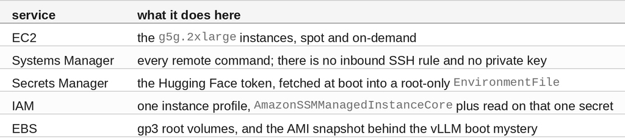

#### Clean Up

Every instance is terminated as soon as its artifacts are captured. There is no built image to lose, only a pip install and a model cache.

```
terminate_g5g_instance i-02e79988a6cbeecbf
```

```
🗑️ Terminating `i-02e79988a6cbeecbf`. Relaunch costs a pip install, not a build.
```

```bash
aws ec2 describe-instances --filters "Name=instance-state-name,Values=running" \
  --query 'Reservations[].Instances[?starts_with(InstanceType,`g5g`)].InstanceId' \
  --output text | grep . || echo "🟢 none running"
```

```
🟢 none running
```

#### What This Does Not Cover

Everything above is concurrency one, which makes it a latency comparison rather than a serving one. Continuous batching is vLLM's whole value proposition and it is untested here.

Only vLLM can serve concurrently at all today. The PyTorch server holds an `asyncio.Lock` with the comment *"one GPU, one process -> serialize requests"*, and the JAX rig has no batching machinery whatever. The engine-level batch sweep suggests what is on the table — batch eight reaches 84.16 tok/s for an extra 0.258 GB, with per-step time growing two percent across an eight-fold batch — but that number never leaves the engine.

Three further gaps: the JAX leg ran its shipped quantised configuration against two dense runtimes; no output-quality axis was measured at all, on a comparison where one runtime uses a deliberately lossy LM head; and every TTFT figure predates the prompt-uniqueness fix, so only the JAX versus PyTorch half of that table is sound.

#### Summary

The goal of this article was to compare three inference runtimes on identical silicon without the harness being a variable. The key to the solution was a single client-side statistic that every OpenAI-compatible server can produce. The measured results were:

- Decode at concurrency one: vLLM 32.53, JAX 12.69, PyTorch 10.24 tok/s — 53, 21 and 17 percent of a 61.4 tok/s bandwidth ceiling, so none is bandwidth-bound.
- The ranking reverses on lifecycle. Cold boot 195.2 s for PyTorch against 1417.8 s for vLLM; a code change costs 25 s against a from-source rebuild.
- JAX prefills 2.4x slower than PyTorch, 1.403 against 0.595 ms/token.
- A 94.7 percent prefix-cache hit rate turned a 30x TTFT result into a harness artifact.
- Calibration offsets are per-rig, 0.9799 and 0.9543, and are not transferable.
- Boot variance is about 12 percent on this platform regardless of runtime.
- The whole exercise cost under $3 in total. That is what made discarding a finished campaign over a poll-interval bug a twenty minute decision rather than an argument.

Scope: the decode and boot numbers are one `g5g.2xlarge` per runtime in `us-east-1a` on 2026-08-31, three repeats per cell and three repeats per boot, mixed spot and on-demand with the market recorded per run. Three things differed between the legs and are named where they matter: vLLM ran `max_model_len` 16384 against 4096 for the other two; the JAX leg ran its shipped quantised configuration against two dense runtimes; and vLLM booted from a prebuilt AMI carrying its model cache while the other two installed from wheels and downloaded the checkpoint, which is the point of the boot comparison rather than a flaw in it. Two runs sit outside that envelope and say so in the text: the RAM test was a single `g5g.4xlarge`, and the prefetch A/B ran 2026-09-01 on on-demand after a spot reclamation killed the first attempt. Decode is unaffected by the prefix-cache issue, which changes prefill only.

The strategy for using MCP for multi-runtime comparison was validated with a incremental step by step approach.